# Latent Dirichlet Allocation

## Topic Modeling: LDA

While supervised learning is used when we know the categories we want to produce, unsupervised learning (including topic modeling) is used when we do not know the categories. In topic modeling, documents are not assumed to belong to one topic or category, but simultaneously belong to several topics. The topic distributions also vary over documents.

The workhorse function for the topic model is `LDA`, which stands for Latent Dirichlet Allocation, the technical name for this particular kind of model.

We will now use a dataset that contains the lead paragraph of around 5,000 articles about the economy published in the New York Times between 1980 and 2014. As before, we will preprocess the text using the standard set of techniques.

The number of topics in a topic model is somewhat arbitrary, so you need to play with the number of topics to see if you get anything more meaningful. We start here with 30 topics.

```r
# reading data and preparing corpus object
nyt <- read.csv("data/nytimes.csv", stringsAsFactors = FALSE)
nytcorpus <- corpus(nyt$lead_paragraph)
nytdfm <- dfm(nytcorpus, remove=stopwords("english"), verbose=TRUE,
               remove_punct=TRUE, remove_numbers=TRUE)
cdfm <- dfm_trim(nytdfm, min_docfreq = 2)
# estimate LDA with K topics
K <- 30
lda <- LDA(cdfm, k = K, method = "Gibbs",
                control = list(verbose=25L, seed = 123, burnin = 100, iter = 500))
```

```
## K = 30; V = 11150; M = 5000
## Sampling 600 iterations!
## Iteration 25 ...
## Iteration 50 ...
## Iteration 75 ...
## Iteration 100 ...
## Iteration 125 ...
## Iteration 150 ...
## Iteration 175 ...
## Iteration 200 ...
## Iteration 225 ...
## Iteration 250 ...
## Iteration 275 ...
## Iteration 300 ...
## Iteration 325 ...
## Iteration 350 ...
## Iteration 375 ...
## Iteration 400 ...
## Iteration 425 ...
## Iteration 450 ...
## Iteration 475 ...
## Iteration 500 ...
## Iteration 525 ...
## Iteration 550 ...
## Iteration 575 ...
## Iteration 600 ...
## Gibbs sampling completed!
```

We can use `get_terms` to the top `n` terms from the topic model, and `get_topics` to predict the top `k` topic for each document. This will help us interpret the results of the model.

```r
terms <- get_terms(lda, 15)
terms[,1]
```

```
##  [1] "americans" "people"    "income"    "among"     "s"         "poverty"
##  [7] "life"      "personal"  "less"      "poor"      "decade"    "working"
## [13] "much"      "study"     "according"
```

```r
topics <- get_topics(lda, 1)
head(topics)
```

```
## text1 text2 text3 text4 text5 text6
##     1    11    25    18    23    30
```

Let’s take a closer look at some of these topics. To help us interpret the output, we can look at the words associated with each topic and take a random sample of documents highly associated with each topic.

```r
# Topic 2
paste(terms[,2], collapse=", ")
```

```
## [1] "$, billion, year, million, money, week, last, nation's, supply, deficit, nearly, measure, ended, trillion, previous"
```

```r
sample(nyt$lead_paragraph[topics==2], 1)
```

```
## [1] "The Government took in $15.61 billion more than it spent in January, the Treasury Department said on Wednesday. The surplus in January was not as large as in January 1993, when there was a $29.82 billion surplus. But it was a sharp reversal from December's deficit of $8.25 billion."
```

```r
# Topic 3
paste(terms[,3], collapse=", ")
```

```
## [1] "percent, department, reported, today, rose, commerce, said, month, decline, goods, increase, orders, fell, february, since"
```

```r
sample(nyt$lead_paragraph[topics==3], 1)
```

```
## [1] "Inflation hit double figures in most countries last year, but there is a glimmer of hope that the rate may eventually drop, the International Labor Organization said today. A survey of 65 representative countries throughout the world showed that inflation ranged from 3.8 percent in Switzerla…
```

```r
# Topic 7
paste(terms[,7], collapse=", ")
```

```
## [1] "said, today, mr, officials, treasury, secretary, made, told, next, official, meeting, saying, top, announced, several"
```

```r
sample(nyt$lead_paragraph[topics==7], 1)
```

```
## [1] "An Opportunity On Executive Pay He who pays the piper supposedly calls the tune. And Henry Paulson, the Treasury secretary, is rightly insisting on some restrictions on bank bosses' pay while their firms are benefiting from government cash. But the Treasury should show more ambition to chang…
```

```r
# Topic 12
paste(terms[,12], collapse=", ")
```

```
## [1] "one, like, can, another, part, every, way, problem, least, line, face, made, see, without, look"
```

```r
sample(nyt$lead_paragraph[topics==12], 1)
```

```
## [1] "COMPANIES In a Changing Air-Travel Market, Delta Tries a Fresh Start It was the latest admission that the business of air travel has changed -- for good. Back when a plane ticket was a luxury item, not a well-worn commodity like a pair of jeans, airlines used to make a lot of money. But then…
```

You will that often some topics do not make much sense. They just capture the remaining cluster of words, and often correspond to stopwords. For example:

```r
# Topic 14
paste(terms[,14], collapse=", ")
```

```
## [1] "now, much, may, many, far, less, almost, even, yet, well, however, also, little, past, become"
```

```r
sample(nyt$lead_paragraph[topics==14], 1)
```

```
## [1] "The conventional wisdom is that the chances of Congress passing a bill that puts both a cap and a price on greenhouse gases are somewhere between terrible and nil. President Obama can start to prove the conventional wisdom wrong by making a full-throated case for a climate bill in his State …
```

In the case of date with timestamps, looking at the evolution of certain topics over time can also help interpret their meaning. Let’s look for example at Topic 23, which appears to be related to the stock market.

```r
# Topic 2
paste(terms[,23], collapse=", ")
```

```
## [1] "market, stock, wall, street, investors, stocks, yesterday, points, markets, average, week, dow, industrial, day, trading"
```

```r
sample(nyt$lead_paragraph[topics==23], 1)
```

```
## [1] "For weeks, many of Wall Street's hopeful voices have been calling the end of the recession. And when the Federal Reserve chairman, Ben S. Bernanke, said the same was ''very likely'' on Tuesday, his comment helped stock markets rise to highs for the year. The Dow Jones industrial average gain…
```

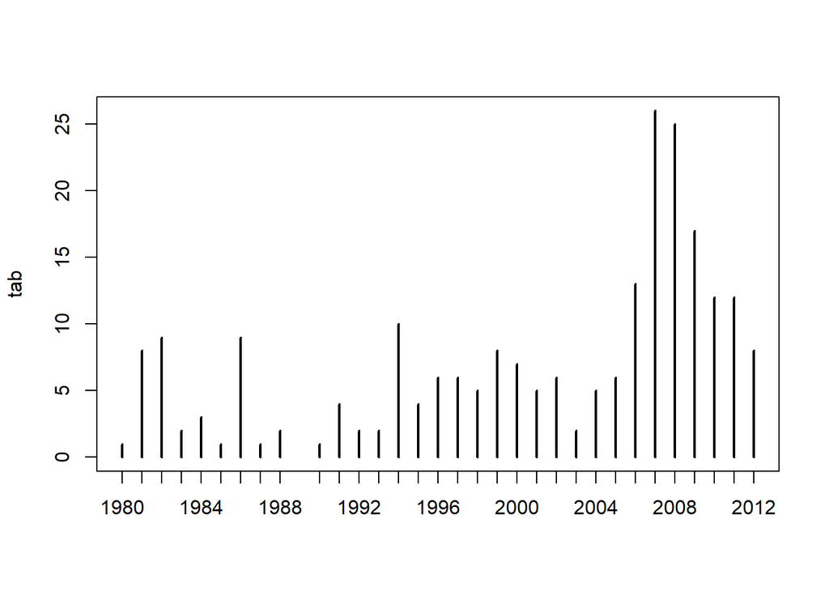

```r
# add predicted topic to dataset
nyt$pred_topic <- topics
nyt$year <- substr(nyt$datetime, 1, 4) # extract year
 # frequency table with articles about stock market, per year
tab <- table(nyt$year[nyt$pred_topic==23])
plot(tab)
```

But we can actually do better than this. LDA is a probabilistic model, which means that for each document, it actually computes a distribution over topics. In other words, each document is considered to be **about a mixture of topics**.

This information is included in the matrix `gamma` in the LDA object (`theta` in the notation we used for the slides). For example, article 1 is 15% about topic 1, 5% about topics 5, 6, 8, and 21, and then less than 5% for each of the rest.

```r
# 5000 docs, 30 topics
dim(lda@gamma)
```

```
## [1] 5000   30
```

```r
# probability of topic given the document
round(lda@gamma[1,], 2)
```

```
##  [1] 0.15 0.04 0.02 0.02 0.05 0.05 0.02 0.05 0.02 0.02 0.03 0.02 0.02 0.02 0.02
## [16] 0.03 0.03 0.04 0.02 0.02 0.05 0.03 0.04 0.02 0.02 0.02 0.02 0.04 0.02 0.02
```

```r
# ... sum up to 1 as they should
sum(lda@gamma[1,])
```

```
## [1] 1
```

So we can actually take the information in the matrix and aggregate it to compute the average probability that an article each year is about a particular topic. Let’s now choose Topic 29, which appears to be related to the financial crisis.

```r
# Topic 15
paste(terms[,29], collapse=", ")
```

```
## [1] "financial, banks, crisis, credit, bank, debt, money, system, loans, mortgage, capital, funds, markets, fund, savings"
```

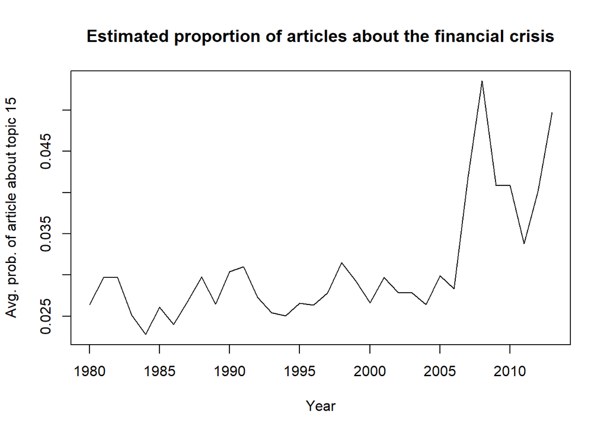

```r
# add probability to df
nyt$prob_topic <- lda@gamma[,29]
# now aggregate at the year level
agg <- aggregate(nyt$prob_topic, by=list(year=nyt$year), FUN=mean)
# and plot it
plot(agg$year, agg$x, type="l", xlab="Year", ylab="Avg. prob. of article about topic 15",
     main="Estimated proportion of articles about the financial crisis")
```